# Tutorial for InterSpatial

Tuhin Majumder

2024-11-25

# Loading the required libraries

```r
library(InterSpatial)
library(Seurat)
library(HGC)
library(pheatmap)
```

# Preprocessing of the input datasets

InterSpatial uses two major inputs - gene expression of single cells, and the gene expression of the visium data. Ideally, the single-cell data input is a Seurat object with `.rds` file extension. A gene by cell count matrix is also fine as input, with the row names as gene names and the column names as cell ids. In this case, a Seurat object is created with an optional `metadata` input. The Seurat object is then transformed using `SCTransform` normalization from Seurat package. The full operation is carried out by the function `transform_scRNA_data`, starting from creating a Seurat object (if needed) and then applying the required transformation. The output Seurat object contains the input assays (typically the `RNA` assay) and the `SCT` assay.

The visium data input must be a `.h5` file from the Space Ranger output, containing gene count matrix for the spots. We recommend separate directories for each visium sample which should contain the “spatial” folder and the input `.h5` file. The `SCTransform` should be then applied to the visium data using `transform_spatial_data` function.

## Processing scRNA-seq data

```r
## Read scRNA data
toy_scrna_path <- system.file("extdata", "toy_scRNA", "mouse_brain_small.rds", package = "InterSpatial")
dat_scRNA <- readRDS(toy_scrna_path)


#Transform scRNA data

dat_scRNA <- transform_scRNA_data(dat_scRNA)
```

## Processing Visium data

```r
## Load visium Data
# Change the data location with user's convenience
visium.data.dir = "../inst/extdata/toy_visium/"
dat_visium <- Load10X_Spatial(visium.data.dir,
                        filename = "mouse_filtered_feature_bc_matrix.h5",
                        assay = "Spatial",
                        slice = "slice",
                        filter.matrix = TRUE,
                        to.upper = FALSE,
                        image = NULL)


## Transform the visium data
dat_visium <- transform_spatial_data(dat_visium)
```

# Create cell by spot probability matrix

From the transformed input data sets, we developed an algorithm to map the single cells onto visium spots. The function `create_probability_matrix` creates a cell by spot probability, each row corresponding to a cell and each column to a spot. The rows with sum $1$ represent the cell-specific probability mapping vectors of those cells, and the rows with sum $0$ represent the cells not mapped to the visium data at all. Thus, InterSpatial inheriently removes the cells uncorrelated with the visium spots from the analysis.

```r
## Create Probability matrix

prob_matrix <- create_probability_matrix(dat_scRNA = dat_scRNA,dat_visium = dat_visium, p_hvg=50, num_pca = 10, alpha=0.05, nCores=8)
```

# Creating meta-cells

Next, we use `HGC` package to cluster the scRNA-seq data into a few meta-cells, and then attribute the meta-cells to their most common cell type. In practice, we fix the number of meta-cells to an integer so that on average each meta-cell has $80-100$ single cells. `HGC` produces meta-cells of uniform size, and generally these meta-cells have one dominant cell-type, as shown in the figure.

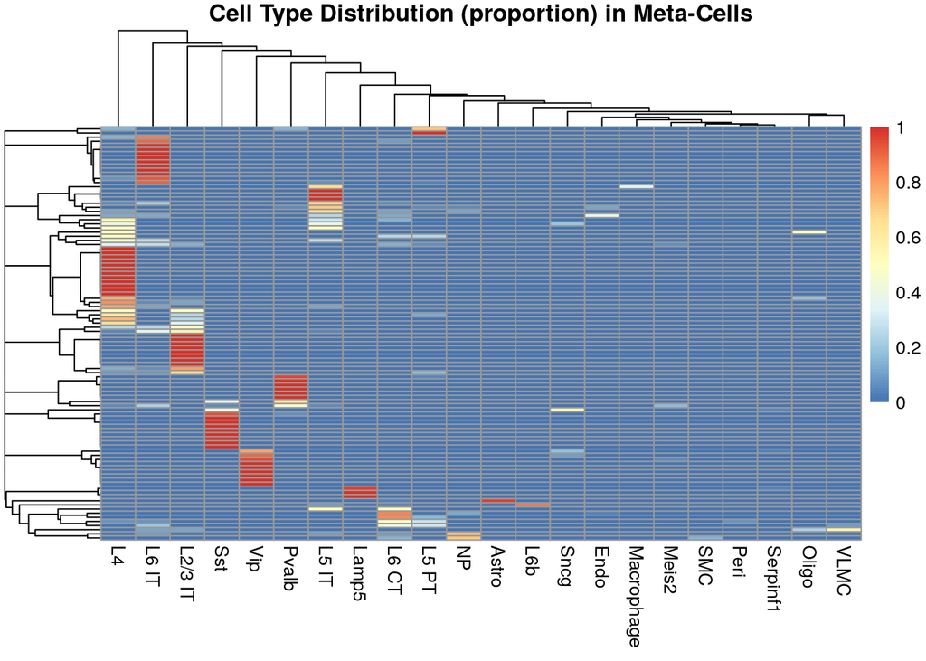

```r
## Create Probability matrix

cluster_HGC_scRNA <- find_cluster_scRNA_HGC(dat_scRNA = dat_scRNA,k=100,num_pca = 10,p_hvg=50, cell_type_column = "subclass")

cell_type_proportion_meta_cells <- attr(cluster_HGC_scRNA,"cell_type_proportion_meta_cells")
pheatmap(cell_type_proportion_meta_cells ,Rowv=F, scale='none', symm = T,main = paste0("Cell Type Distribution (proportion) in Meta-Cells"),
         show_rownames = F)
```

## Constructing meta-cell mapping

Once, we get the meta-cells, we compute the spatial mapping of the meta-cells by averaging the individual mapping probabilities in each spot.

```r
## Compute meta-cell probability mapping

prob_data_hier_cluster <- compute_all_clusters_prob_matrix(prob_data = prob_matrix,cluster_labels = cluster_HGC_scRNA)
```

# Compute meta-cell to meta-cell Wasserstein distance

## Computing meta-cell to meta-cell distances for arbitrary source and receiving meta-cells

In this section,we compute the pairwise wasseretsin distance between source meta-cells and the receiver meta-cells. These source and receiving meta-cells ids need to be provided as input, along with the spot-spot distance matrix. This distance matrix can be constructed from the $(x,y)$ co-ordinates of the visium spots.

```r
source_cell_type <- "Vip"
receiving_cell_type <- "L4"

nnz_meta_cells <- which(rowSums(prob_data_hier_cluster)>0)
source_meta_cells <- intersect(which(cell_type_proportion_meta_cells[,source_cell_type]>0.5),
                               nnz_meta_cells)
receving_meta_cells <- intersect(which(cell_type_proportion_meta_cells[,receiving_cell_type]>0.5),
                                 nnz_meta_cells)

D <- create_distance_matrix(prob_data = prob_data_hier_cluster,dat_visium = dat_visium,
                            visium.data.dir = visium.data.dir )

distances <- compute_wasserstein_distance(prob_data=prob_data_hier_cluster,
                                          source_cell_id = source_meta_cells,
                                          receiver_cell_id = receving_meta_cells,
                                          Distance_Matrix = D,
                                          nCores = 4,
                                          parallelize = "FALSE",
                                          out_dir = "/cwork/tm389")
```

## Computing Wasserstein distances between meta-cells of different cell types

If the scRNA-seq dataset has a cell type identification in the metadata, we can construct meta-cells from these cell types and compute the Wasserstein distance between the meta-cells of source cell type and reciver cell types. Here, we have two optional input `thres_source_proportion` and `thres_receiver_proportion` with default value $0.5$, which indicates if the proportion of cell types are more than these thresholds in the meta-cell, we label them as source or receiver respectively.

```r
distances_2 <- compute_wasserstein_distance_between_cell_type(prob_data=prob_data_hier_cluster, dat_visium = dat_visium,
                                                              visium.data.dir=visium.data.dir,
                                                              source_cell_type = "Sst",
                                                              receiver_cell_type = "L6 IT",
                                                              cluster_labels = cluster_HGC_scRNA,
                                                              nCores=4)
```

# Inferring CCC

From the Wasserstein distances between source and reciever cell-types, we can compute the Kendall’s-$\tau$ between the receptor’s expression in receiving meta cells, and their nearest optimal transport distances (NOTD) from the source. We also visualize the trend in a scatterplot.

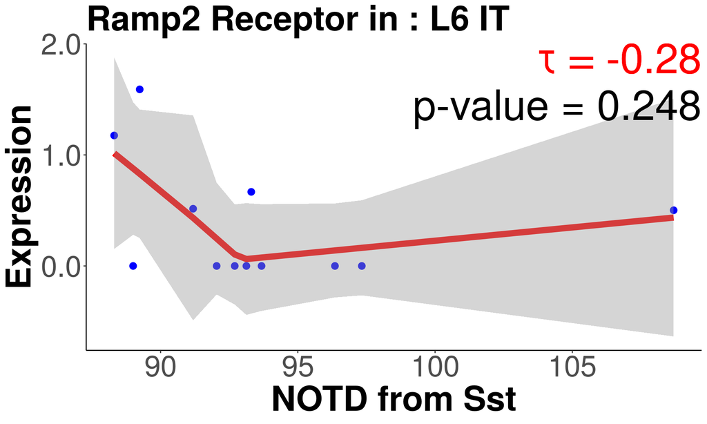

```r
library(dplyr)
library(ggplot2)
all_gene_count_meta_cell <- create_meta_cell_gene_count_matrix(dat_scRNA = dat_scRNA, cluster_labels =cluster_HGC_scRNA )

data(ligand_receptor_interactions_mouse)

## Most Expressed genes in source

Exp_source <- colMeans(all_gene_count_meta_cell[unique(distances_2$wasserstein_distance$clust_ind_source),])
top_genes <- names(sort(Exp_source,decreasing = TRUE))[1:10]


scRNA_receptors <- intersect(colnames(all_gene_count_meta_cell) ,
                             unlist(strsplit(ligand_receptor_interactions_mouse$receptor.symbol, ",\\s*")))

all_tau <- as.data.frame(t(sapply(scRNA_receptors, function(x)compute_tau(distances_2, all_gene_count_meta_cell,  x)) ))


plot_receptor_expression(distances_2, all_gene_count_meta_cell,  "Ramp2")
```